# Лабораторная работа № 3

Настройка DHCP-сервера

Баранов Никита Дмитриевич

1132242977@rudn.ru

Российский университет дружбы народов им. Патриса Лумумбы

2026-09-14

# Информация

## Докладчик

- Баранов Никита Дмитриевич
- Студент РУДН
- 1132242977@rudn.ru

# Цель и задачи

## Цель работы

- Приобрести навыки установки и конфигурирования DHCP-сервера.

## Основные этапы

- Установлен Kea DHCP и создан пул адресов для внутренней сети.
- В kea-dhcp4.conf заданы подсеть 192.168.1.0/24, диапазон клиентов, DNS-сервер и домен.
- Открыт сервис DHCP, запущена и включена служба kea-dhcp4.
- На клиенте активирован интерфейс eth1; получен адрес 192.168.1.30/24.
- Настроен Kea DHCP-DDNS и разрешено динамическое обновление зоны BIND.
- Запрос dig к client.ndbaranov.net вернул адрес клиента.
- Команда vagrant validate подтвердила корректность автоматизации.

# Ход работы

## Установка Kea DHCP

- На сервер установлен Kea DHCP4.

[figure not shown]

## Описание подсети и пула

- В kea-dhcp4.conf задана сеть 192.168.1.0/24, диапазон динамических адресов и параметры DNS.

[figure not shown]

## Запуск DHCP4

- Служба kea-dhcp4 включена и запущена, в firewalld разрешён DHCP.

[figure not shown]

## Получение адреса клиентом

- После активации интерфейса client получает динамический адрес 192.168.1.30/24.

[figure not shown]

## Параметры DHCP-аренды

[figure not shown]

## Настройка DHCP-DDNS

- Включено взаимодействие Kea DHCP-DDNS с BIND.

[figure not shown]

## Динамическая запись клиента

- Запрос dig к client.ndbaranov.net возвращает адрес выданной аренды.

[figure not shown]

## Проверка обратного обновления

[figure not shown]

## Диагностика Vagrantfile

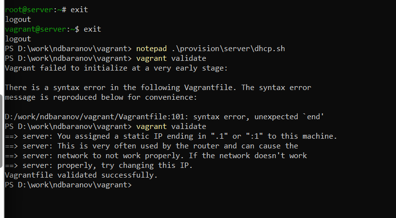

# Результаты

## Итоги работы

- Сервер Kea выдаёт клиенту адрес и параметры внутренней сети. DHCP-DDNS автоматически создаёт DNS-запись client.ndbaranov.net, что подтверждено сетевыми проверками.

## Спасибо за внимание